# **Classifying Hypertension Risk in the African-American Community Using NHANES Data**

## **Problem Statement**

Hypertension, or high blood pressure, is a critical public health concern in the United States, disproportionately affecting the African-American community. Studies show that African-Americans develop hypertension earlier and at higher rates than other racial groups, leading to increased risks of heart disease, stroke, and other complications.

The goal of this project is to build a **classification model** that predicts an individual's risk of hypertension based on lifestyle and socioeconomic factors using data from the **National Health and Nutrition Examination Survey (NHANES)**. By identifying key predictors such as **age, diet, physical activity, and healthcare access**, this model can help improve early detection and preventive strategies.

## **Research Questions**

This study aims to answer the following key questions:

- What are the most important predictors of hypertension in the African-American community?
- How well can a machine learning model classify individuals as hypertensive or non-hypertensive based on NHANES data?
- Can insights from this model inform targeted health interventions to reduce hypertension risk?

## **Importance of the Study**

Hypertension is a major contributor to health disparities in the U.S., particularly among African-Americans. If we can better understand the lifestyle and socioeconomic factors contributing to high blood pressure, we can develop more effective **public health strategies** and **personalized interventions**. However, ethical concerns such as **data bias and misinterpretation of findings** must be carefully considered to ensure responsible and fair use of predictive modeling in healthcare.

## **Data Source**

The dataset used for this project comes from the **National Health and Nutrition Examination Survey (NHANES)**, which is publicly available through the Centers for Disease Control and Prevention (CDC). NHANES collects extensive health-related data through physical examinations, laboratory tests, and surveys.

📌 **Source:**

- [CDC NHANES Data](https://wwwn.cdc.gov/nchs/nhanes/)
- [NHANES on Kaggle](https://www.kaggle.com/datasets/cdc/national-health-and-nutrition-examination-survey)

## **Dataset Overview**

To build a classification model for hypertension risk, we will use the following NHANES datasets:

1. **Demographics Data (`demographic.csv`)**
   - Includes participant age, gender, race, education, and income.
   - Key Variables:
     - `RIDRETH1` → Race/Ethnicity (filtering for African-Americans)
     - `RIDAGEYR` → Age
     - `RIAGENDR` → Gender
     - `DMDEDUC2` → Education level
     - `INDHHIN2` → Household income
2. **Examination Data (`examination.csv`)**
   - Contains direct measurements, including **blood pressure readings**.
   - Key Variables:
     - `BPXSY1`, `BPXDI1` → First systolic & diastolic blood pressure reading
     - `BPXSY2`, `BPXDI2` → Second systolic & diastolic reading
     - **Hypertension Definition:** Systolic BP ≥ 130 mmHg or Diastolic BP ≥ 80 mmHg
3. **Dietary Data (`dietary.csv`)**
   - Provides information on **nutrient intake**.
   - Key Variables:
     - `DR1TSODI` → Sodium intake
     - `DR1TKCAL` → Total daily calories
     - `DR1TPOTA` → Potassium intake
4. **Physical Activity Data (`physical_activity.csv`)**
   - Measures **physical activity levels**.
   - Key Variables:
     - `PAQ605` → Days of moderate activity per week
     - `PAQ620` → Days of vigorous activity per week
5. **Healthcare Access Data (`questionnaire.csv`)**
   - Captures access to healthcare and general health perception.
   - Key Variables:
     - `HIQ011` → Health insurance status (Yes/No)
     - `HUQ030` → General health condition (Excellent/Poor)

## **Why This Dataset?**

- **Comprehensive Data**: NHANES offers detailed health and lifestyle factors crucial for predicting hypertension.
- **Real-world Relevance**: The data is collected through nationally representative sampling, making it valuable for understanding public health trends.
- **Feature Availability**: The dataset includes key risk factors such as **age, diet, physical activity, and healthcare access**, allowing us to explore their relationship with hypertension.

```python
import pandas as pd


demographics = pd.read_csv(r"/Users/orlandobrandon/Desktop/Portfolio Files/orlandobrandon.github.io/Project_2/demographic.csv")
examination = pd.read_csv(r"/Users/orlandobrandon/Desktop/Portfolio Files/orlandobrandon.github.io/Project_2/examination.csv")
dietary = pd.read_csv(r"/Users/orlandobrandon/Desktop/Portfolio Files/orlandobrandon.github.io/Project_2/diet.csv")
questionnaire = pd.read_csv(r"/Users/orlandobrandon/Desktop/Portfolio Files/orlandobrandon.github.io/Project_2/questionnaire.csv")

# Filter for African-American participants
african_american_data = demographics[demographics["RIDRETH1"] == 4]  # 4 corresponds to African-Americans

# Merge datasets on 'SEQN'
merged_df = african_american_data.merge(examination, on="SEQN", how="inner")
merged_df = merged_df.merge(dietary, on="SEQN", how="inner")
merged_df = merged_df.merge(questionnaire, on="SEQN", how="inner")

# Handle missing values (drop rows with too many missing values)
merged_df = merged_df.dropna(subset=["BPXSY1", "BPXDI1", "DR1TSODI", "PAQ605", "HIQ011"])

# Define Hypertension Label (1 = Hypertensive, 0 = Non-Hypertensive)
merged_df["Hypertension"] = ((merged_df["BPXSY1"] >= 130) | (merged_df["BPXDI1"] >= 80)).astype(int)

# Display the first few rows using Pandas
print(merged_df.head())
```

```
     SEQN  SDDSRVYR  RIDSTATR  RIAGENDR  RIDAGEYR  RIDAGEMN  RIDRETH1  \
0   73557         8         2         1        69       NaN         4
4   73576         8         2         1        16       NaN         4
5   73580         8         2         2        38       NaN         4
9   73600         8         2         1        37       NaN         4
10  73613         8         2         2        60       NaN         4

    RIDRETH3  RIDEXMON  RIDEXAGM  ...  WHD080L  WHD110  WHD120  WHD130  \
0          4       1.0       NaN  ...     40.0   270.0   200.0    69.0
4          4       2.0     194.0  ...      NaN     NaN     NaN     NaN
5          4       1.0       NaN  ...      NaN   190.0   190.0     NaN
9          4       2.0       NaN  ...      NaN   250.0   275.0     NaN
10         4       2.0       NaN  ...      NaN   185.0   150.0    66.0

    WHD140  WHQ150  WHQ030M  WHQ500  WHQ520  Hypertension
0    270.0    62.0      NaN     NaN     NaN             0
4      NaN     NaN      NaN     NaN     NaN             0
5    220.0    37.0      NaN     NaN     NaN             1
9    300.0    30.0      NaN     NaN     NaN             1
10   263.0    55.0      NaN     NaN     NaN             1

[5 rows x 1390 columns]
```

```python
import pandas as pd
import numpy as np
```

```python
merged_df["Hypertension"].value_counts()
```

```
Hypertension
0    762
1    462
Name: count, dtype: int64
```

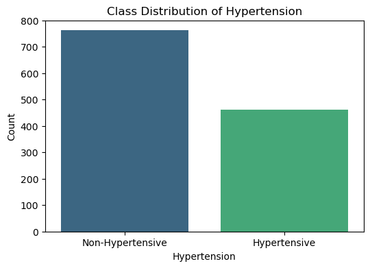

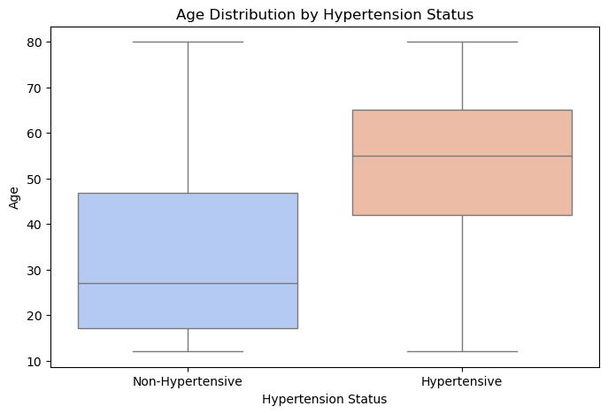

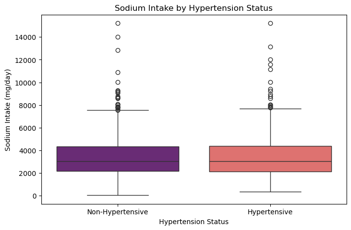

```python
import matplotlib.pyplot as plt
import seaborn as sns

# Class Distribution of Hypertension
plt.figure(figsize=(6,4))
sns.barplot(x=merged_df["Hypertension"].value_counts().index,
            y=merged_df["Hypertension"].value_counts().values,
            palette="viridis")
plt.xticks(ticks=[0, 1], labels=["Non-Hypertensive", "Hypertensive"])
plt.ylabel("Count")
plt.title("Class Distribution of Hypertension")
plt.show()

# Age vs. Hypertension
plt.figure(figsize=(8,5))
sns.boxplot(x=merged_df["Hypertension"], y=merged_df["RIDAGEYR"], palette="coolwarm")
plt.xticks(ticks=[0, 1], labels=["Non-Hypertensive", "Hypertensive"])
plt.xlabel("Hypertension Status")
plt.ylabel("Age")
plt.title("Age Distribution by Hypertension Status")
plt.show()

# Sodium Intake vs. Hypertension
plt.figure(figsize=(8,5))
sns.boxplot(x=merged_df["Hypertension"], y=merged_df["DR1TSODI"], palette="magma")
plt.xticks(ticks=[0, 1], labels=["Non-Hypertensive", "Hypertensive"])
plt.xlabel("Hypertension Status")
plt.ylabel("Sodium Intake (mg/day)")
plt.title("Sodium Intake by Hypertension Status")
plt.show()
```

```python
import os
print(os.listdir())  # all files in the current directory
```

```
['medications.csv', '.DS_Store', 'diet.csv', 'Project 2 Blood Pressure analysis.ipynb', 'examination.csv', '.ipynb_checkpoints', 'demographic.csv', 'labs.csv', 'questionnaire.csv']
```

```python
import pandas as pd

# Load each dataset one by one to check contents
datasets = ["medications.csv", "diet.csv", "examination.csv", "demographic.csv", "labs.csv", "questionnaire.csv"]

for file in datasets:
    print(f"\nLoading {file}...")
    df = pd.read_csv(file, encoding="latin1")


    print(df.head())
    print(df.columns)
```

```
Loading medications.csv...
    SEQN  RXDUSE           RXDDRUG RXDDRGID  RXQSEEN  RXDDAYS RXDRSC1 RXDRSC2  \
0  73557       1             99999      NaN      NaN      NaN     NaN     NaN
1  73557       1           INSULIN   d00262      2.0   1460.0     E11     NaN
2  73558       1        GABAPENTIN   d03182      1.0    243.0  G25.81     NaN
3  73558       1  INSULIN GLARGINE   d04538      1.0    365.0     E11     NaN
4  73558       1        OLMESARTAN   d04801      1.0     14.0   E11.2     NaN

  RXDRSC3                                            RXDRSD1 RXDRSD2 RXDRSD3  \
0     NaN                                                NaN     NaN     NaN
1     NaN                           Type 2 diabetes mellitus     NaN     NaN
2     NaN                             Restless legs syndrome     NaN     NaN
3     NaN                           Type 2 diabetes mellitus     NaN     NaN
4     NaN  Type 2 diabetes mellitus with kidney complicat...     NaN     NaN

   RXDCOUNT
0       2.0
1       2.0
2       4.0
3       4.0
4       4.0
Index(['SEQN', 'RXDUSE', 'RXDDRUG', 'RXDDRGID', 'RXQSEEN', 'RXDDAYS',
       'RXDRSC1', 'RXDRSC2', 'RXDRSC3', 'RXDRSD1', 'RXDRSD2', 'RXDRSD3',
       'RXDCOUNT'],
      dtype='object')

Loading diet.csv...
    SEQN         WTDRD1         WTDR2D  DR1DRSTZ  DR1EXMER  DRABF  DRDINT  \
0  73557   16888.327864   12930.890649         1      49.0    2.0     2.0
1  73558   17932.143865   12684.148869         1      59.0    2.0     2.0
2  73559   59641.812930   39394.236709         1      49.0    2.0     2.0
3  73560  142203.069917  125966.366442         1      54.0    2.0     2.0
4  73561   59052.357033   39004.892993         1      63.0    2.0     2.0

   DR1DBIH  DR1DAY  DR1LANG  ...  DRD370QQ  DRD370R  DRD370RQ  DRD370S  \
0      6.0     2.0      1.0  ...       NaN      NaN       NaN      NaN
1      4.0     1.0      1.0  ...       NaN      2.0       NaN      2.0
2     18.0     6.0      1.0  ...       NaN      NaN       NaN      NaN
3     21.0     3.0      1.0  ...       NaN      NaN       NaN      NaN
4     18.0     1.0      1.0  ...       NaN      2.0       NaN      2.0
```

[output cut: 123 more lines]

```

   WHQ030M  WHQ500  WHQ520
0      NaN     NaN     NaN
1      NaN     NaN     NaN
2      NaN     NaN     NaN
3      3.0     3.0     3.0
4      NaN     NaN     NaN

[5 rows x 953 columns]
Index(['SEQN', 'ACD011A', 'ACD011B', 'ACD011C', 'ACD040', 'ACD110', 'ALQ101',
       'ALQ110', 'ALQ120Q', 'ALQ120U',
       ...
       'WHD080U', 'WHD080L', 'WHD110', 'WHD120', 'WHD130', 'WHD140', 'WHQ150',
       'WHQ030M', 'WHQ500', 'WHQ520'],
      dtype='object', length=953)
```

```python
import pandas as pd

# Load the dietary data (contains sodium intake)
diet_df = pd.read_csv("diet.csv", encoding="latin1")

# Load the examination data (contains blood pressure readings)
exam_df = pd.read_csv("examination.csv", encoding="latin1")

# Merge datasets on SEQN (participant ID)
merged_df = pd.merge(diet_df, exam_df, on="SEQN", how="inner")

# Display the first few rows
print(merged_df.head())
```

```
    SEQN         WTDRD1         WTDR2D  DR1DRSTZ  DR1EXMER  DRABF  DRDINT  \
0  73557   16888.327864   12930.890649         1      49.0    2.0     2.0
1  73558   17932.143865   12684.148869         1      59.0    2.0     2.0
2  73559   59641.812930   39394.236709         1      49.0    2.0     2.0
3  73560  142203.069917  125966.366442         1      54.0    2.0     2.0
4  73561   59052.357033   39004.892993         1      63.0    2.0     2.0

   DR1DBIH  DR1DAY  DR1LANG  ...  CSXLEAOD  CSXSOAOD  CSXGRAOD  CSXONOD  \
0      6.0     2.0      1.0  ...       2.0       1.0       1.0      1.0
1      4.0     1.0      1.0  ...       3.0       1.0       2.0      3.0
2     18.0     6.0      1.0  ...       2.0       1.0       2.0      3.0
3     21.0     3.0      1.0  ...       NaN       NaN       NaN      NaN
4     18.0     1.0      1.0  ...       3.0       1.0       4.0      3.0

   CSXNGSOD  CSXSLTRT  CSXSLTRG  CSXNART  CSXNARG  CSAEFFRT
0       4.0      62.0       1.0      NaN      NaN       1.0
1       4.0      28.0       1.0      NaN      NaN       1.0
2       4.0      49.0       1.0      NaN      NaN       3.0
3       NaN       NaN       NaN      NaN      NaN       NaN
4       4.0       NaN       NaN      NaN      NaN       1.0

[5 rows x 391 columns]
```

```python
print(merged_df.columns)
```

```
Index(['SEQN', 'WTDRD1', 'WTDR2D', 'DR1DRSTZ', 'DR1EXMER', 'DRABF', 'DRDINT',
       'DR1DBIH', 'DR1DAY', 'DR1LANG',
       ...
       'CSXLEAOD', 'CSXSOAOD', 'CSXGRAOD', 'CSXONOD', 'CSXNGSOD', 'CSXSLTRT',
       'CSXSLTRG', 'CSXNART', 'CSXNARG', 'CSAEFFRT'],
      dtype='object', length=391)
```

```python
# List of important columns we need
important_columns = ["DR1TSODI", "BPXSY1", "BPXDI1"]

# Check which ones exist in merged_df
existing_columns = [col for col in important_columns if col in merged_df.columns]

# Print the result
print("Columns found in merged_df:", existing_columns)
```

```
Columns found in merged_df: ['DR1TSODI', 'BPXSY1', 'BPXDI1']
```

```python
# Drop rows with missing values in key columns
merged_df = merged_df.dropna(subset=["DR1TSODI", "BPXSY1", "BPXDI1"])

# Create a Hypertension label (1 = Hypertensive, 0 = Non-Hypertensive)
merged_df["Hypertension"] = ((merged_df["BPXSY1"] >= 130) | (merged_df["BPXDI1"] >= 80)).astype(int)

# Display the first few rows to verify
print(merged_df[["DR1TSODI", "BPXSY1", "BPXDI1", "Hypertension"]].head())
```

```
   DR1TSODI  BPXSY1  BPXDI1  Hypertension
0    1323.0   122.0    72.0             0
1    9726.0   156.0    62.0             1
2    2943.0   140.0    90.0             1
3    2745.0   108.0    38.0             0
4     797.0   136.0    86.0             1
```

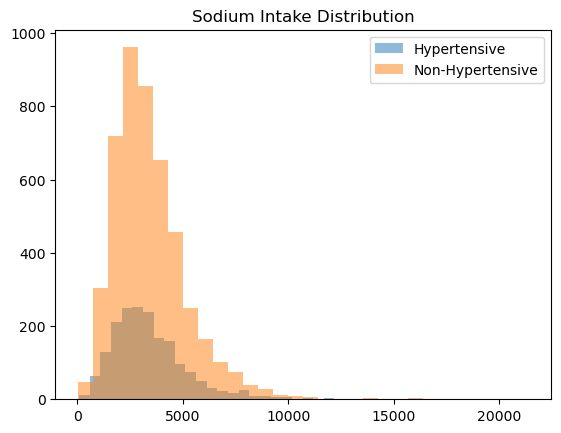

```
T-test: p-value = 0.9402393684346078
Mann-Whitney U test: p-value = 0.6099323309159728
```

```python
from scipy.stats import ttest_ind, mannwhitneyu

# Split sodium intake by hypertension status
sodium_hypertensive = merged_df[merged_df["Hypertension"] == 1]["DR1TSODI"]
sodium_non_hypertensive = merged_df[merged_df["Hypertension"] == 0]["DR1TSODI"]

# Check normality using a histogram (optional)
import matplotlib.pyplot as plt
plt.hist(sodium_hypertensive, bins=30, alpha=0.5, label="Hypertensive")
plt.hist(sodium_non_hypertensive, bins=30, alpha=0.5, label="Non-Hypertensive")
plt.legend()
plt.title("Sodium Intake Distribution")
plt.show()

# Perform T-test (assumes normality)
t_stat, p_value_ttest = ttest_ind(sodium_hypertensive, sodium_non_hypertensive, equal_var=False)

# Perform Mann-Whitney U test (for non-normal data)
u_stat, p_value_mannwhitney = mannwhitneyu(sodium_hypertensive, sodium_non_hypertensive)

# Display results
print(f"T-test: p-value = {p_value_ttest}")
print(f"Mann-Whitney U test: p-value = {p_value_mannwhitney}")
```

```python
# List of datasets to search
datasets = ["medications.csv", "diet.csv", "examination.csv", "demographic.csv", "labs.csv", "questionnaire.csv"]

# Loop through datasets and print columns that contain 'PAQ605' or 'PAQ620'
for file in datasets:
    df = pd.read_csv(file, encoding="latin1")  # Load the dataset
    columns = df.columns.tolist()  # Get all column names

    # Check if PAQ605 or PAQ620 are in the dataset
    if "PAQ605" in columns or "PAQ620" in columns:
        print(f"\n Found in {file}:")
        if "PAQ605" in columns:
            print("   - PAQ605 (Days of moderate activity per week)")
        if "PAQ620" in columns:
            print("   - PAQ620 (Days of vigorous activity per week)")
```

```
 Found in questionnaire.csv:
   - PAQ605 (Days of moderate activity per week)
   - PAQ620 (Days of vigorous activity per week)
```

```python
# Load the questionnaire dataset (which contains PAQ605 and PAQ620)
questionnaire_df = pd.read_csv("questionnaire.csv", encoding="latin1")

# Keep only relevant columns for physical activity
questionnaire_df = questionnaire_df[["SEQN", "PAQ605", "PAQ620"]]

# Merge with the existing merged_df on SEQN (participant ID)
merged_df = merged_df.merge(questionnaire_df, on="SEQN", how="inner")

# Display first few rows to verify merge
print(merged_df[["SEQN", "PAQ605", "PAQ620", "Hypertension"]].head())
```

```
    SEQN  PAQ605  PAQ620  Hypertension
0  73557     2.0     2.0             0
1  73558     2.0     1.0             1
2  73559     2.0     1.0             1
3  73560     NaN     NaN             0
4  73561     2.0     1.0             1
```

```python
# Drop rows with missing physical activity data
merged_df = merged_df.dropna(subset=["PAQ605", "PAQ620"])

# Convert activity columns to integers (if they are float)
merged_df["PAQ605"] = merged_df["PAQ605"].astype(int)
merged_df["PAQ620"] = merged_df["PAQ620"].astype(int)

# Verify that missing values are removed
print(merged_df[["PAQ605", "PAQ620", "Hypertension"]].head())
```

```
   PAQ605  PAQ620  Hypertension
0       2       2             0
1       2       1             1
2       2       1             1
4       2       1             1
5       1       2             1
```

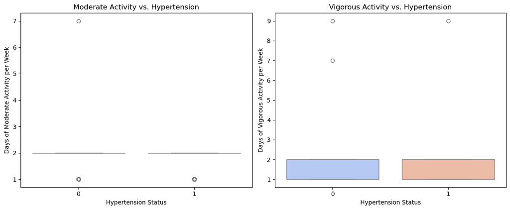

```python
import seaborn as sns
import matplotlib.pyplot as plt

# Set up the figure
plt.figure(figsize=(12, 5))

# Boxplot for moderate activity
plt.subplot(1, 2, 1)
sns.boxplot(x=merged_df["Hypertension"], y=merged_df["PAQ605"], palette="coolwarm")
plt.xlabel("Hypertension Status")
plt.ylabel("Days of Moderate Activity per Week")
plt.title("Moderate Activity vs. Hypertension")

# Boxplot for vigorous activity
plt.subplot(1, 2, 2)
sns.boxplot(x=merged_df["Hypertension"], y=merged_df["PAQ620"], palette="coolwarm")
plt.xlabel("Hypertension Status")
plt.ylabel("Days of Vigorous Activity per Week")
plt.title("Vigorous Activity vs. Hypertension")

# Show plot
plt.tight_layout()
plt.show()
```

```python
from scipy.stats import ttest_ind, mannwhitneyu

# Separate groups
mod_active_hyp = merged_df[merged_df["Hypertension"] == 1]["PAQ605"]
mod_active_nonhyp = merged_df[merged_df["Hypertension"] == 0]["PAQ605"]

vig_active_hyp = merged_df[merged_df["Hypertension"] == 1]["PAQ620"]
vig_active_nonhyp = merged_df[merged_df["Hypertension"] == 0]["PAQ620"]

# T-test
t_test_mod = ttest_ind(mod_active_hyp, mod_active_nonhyp, equal_var=False, nan_policy="omit")
t_test_vig = ttest_ind(vig_active_hyp, vig_active_nonhyp, equal_var=False, nan_policy="omit")

# Mann-Whitney U Test (non-parametric)
mw_test_mod = mannwhitneyu(mod_active_hyp, mod_active_nonhyp, alternative="two-sided")
mw_test_vig = mannwhitneyu(vig_active_hyp, vig_active_nonhyp, alternative="two-sided")

# Print results
print(f"Moderate Activity - T-test p-value: {t_test_mod.pvalue}")
print(f"Moderate Activity - Mann-Whitney U test p-value: {mw_test_mod.pvalue}")

print(f"Vigorous Activity - T-test p-value: {t_test_vig.pvalue}")
print(f"Vigorous Activity - Mann-Whitney U test p-value: {mw_test_vig.pvalue}")
```

```
Moderate Activity - T-test p-value: 0.015663426322191355
Moderate Activity - Mann-Whitney U test p-value: 0.01698060355760848
Vigorous Activity - T-test p-value: 0.20057977522248932
Vigorous Activity - Mann-Whitney U test p-value: 0.19866579668155648
```

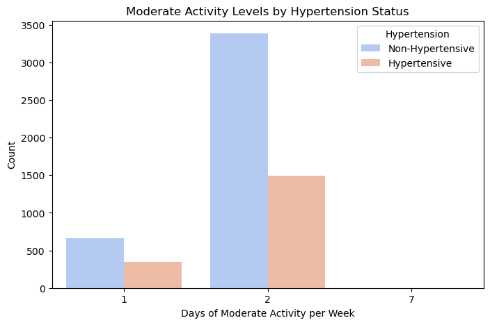

```python
merged_df["PAQ605"] = merged_df["PAQ605"].astype("category")


plt.figure(figsize=(8, 5))
sns.countplot(data=merged_df, x="PAQ605", hue="Hypertension", palette="coolwarm")

plt.xlabel("Days of Moderate Activity per Week")
plt.ylabel("Count")
plt.title("Moderate Activity Levels by Hypertension Status")
plt.legend(title="Hypertension", labels=["Non-Hypertensive", "Hypertensive"])
plt.show()
```

```
PAQ620
2    3901
1    1982
9       2
7       1
Name: count, dtype: int64
```

[figure not shown]

```python
# Count the occurrences of each PAQ620 value
print(merged_df["PAQ620"].value_counts())

# Create a bar chart for vigorous activity
plt.figure(figsize=(8, 5))
sns.histplot(data=merged_df, x="PAQ620", hue="Hypertension", discrete=True, multiple="dodge", shrink=0.8, palette="coolwarm")

# Formatting
plt.xlabel("Days of Vigorous Activity per Week")
plt.ylabel("Count")
plt.title("Vigorous Activity Levels by Hypertension Status")
plt.legend(title="Hypertension", labels=["Non-Hypertensive", "Hypertensive"])
plt.show()
```

```python
from numpy import mean, std
from math import sqrt

# Function to calculate Cohen's d effect size
def cohen_d(group1, group2):
    return (mean(group1) - mean(group2)) / sqrt((std(group1, ddof=1) ** 2 + std(group2, ddof=1) ** 2) / 2)

# Compute effect sizes for moderate and vigorous activity
effect_size_mod = cohen_d(mod_active_hyp.dropna(), mod_active_nonhyp.dropna())
effect_size_vig = cohen_d(vig_active_hyp.dropna(), vig_active_nonhyp.dropna())

# Print effect sizes
print(f"Effect Size (Cohen's d) - Moderate Activity: {effect_size_mod}")
print(f"Effect Size (Cohen's d) - Vigorous Activity: {effect_size_vig}")
```

```
Effect Size (Cohen's d) - Moderate Activity: -0.06843572939872572
Effect Size (Cohen's d) - Vigorous Activity: 0.036055582396037004
```

```python
# Load the questionnaire dataset (contains healthcare access data)
questionnaire_df = pd.read_csv("questionnaire.csv", encoding="latin1")

# Keep only relevant columns for healthcare access
questionnaire_df = questionnaire_df[["SEQN", "HIQ011", "HUQ030"]]

# Merge with the existing merged_df on SEQN (participant ID)
merged_df = merged_df.merge(questionnaire_df, on="SEQN", how="inner")

# Display first few rows to verify merge
print(merged_df[["SEQN", "HIQ011", "HUQ030", "Hypertension"]].head())
```

```
    SEQN  HIQ011  HUQ030  Hypertension
0  73557       1       1             0
1  73558       2       1             1
2  73559       1       1             1
3  73561       1       1             1
4  73562       1       1             1
```

```python
# Convert health insurance to binary (1 = Yes, 2 = No → 1 = Insured, 0 = Not Insured)
merged_df["HIQ011"] = (merged_df["HIQ011"] == 1).astype(int)

# Convert general health (HUQ030) to categorical (1 = Excellent, 5 = Poor)
merged_df["HUQ030"] = merged_df["HUQ030"].astype(int)

# Drop any rows with missing healthcare data
merged_df = merged_df.dropna(subset=["HIQ011", "HUQ030"])

# Verify the changes
print(merged_df[["HIQ011", "HUQ030", "Hypertension"]].head())
```

```
   HIQ011  HUQ030  Hypertension
0       1       1             0
1       0       1             1
2       1       1             1
3       1       1             1
4       1       1             1
```

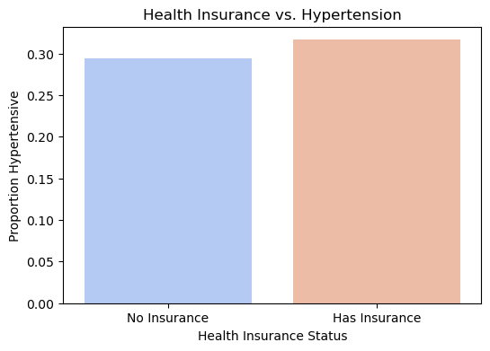

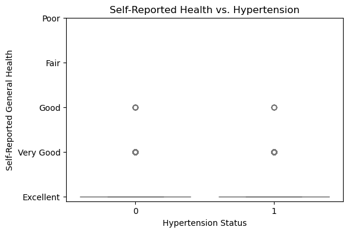

```python
import seaborn as sns
import matplotlib.pyplot as plt

# Bar plot: Health Insurance vs. Hypertension
plt.figure(figsize=(6,4))
sns.barplot(x="HIQ011", y="Hypertension", data=merged_df, ci=None, palette="coolwarm")
plt.xticks(ticks=[0,1], labels=["No Insurance", "Has Insurance"])
plt.ylabel("Proportion Hypertensive")
plt.xlabel("Health Insurance Status")
plt.title("Health Insurance vs. Hypertension")
plt.show()

# Box plot: General Health vs. Hypertension
plt.figure(figsize=(6,4))
sns.boxplot(x="Hypertension", y="HUQ030", data=merged_df, palette="coolwarm")
plt.yticks(ticks=[1,2,3,4,5], labels=["Excellent", "Very Good", "Good", "Fair", "Poor"])
plt.ylabel("Self-Reported General Health")
plt.xlabel("Hypertension Status")
plt.title("Self-Reported Health vs. Hypertension")
plt.show()
```

```python
merged_df["HUQ030"].value_counts()
```

```
HUQ030
1    4936
2     922
3      28
Name: count, dtype: int64
```

```python
# Load the demographic dataset
demographic_df = pd.read_csv("demographic.csv", encoding="latin1")

# Keep only relevant columns
demographic_df = demographic_df[["SEQN", "INDHHIN2", "DMDEDUC2"]]

# Merge with existing dataset
merged_df = merged_df.merge(demographic_df, on="SEQN", how="inner")

# Display first few rows
print(merged_df[["SEQN", "INDHHIN2", "DMDEDUC2", "Hypertension"]].head())
```

```
    SEQN  INDHHIN2  DMDEDUC2  Hypertension
0  73557       4.0       3.0             0
1  73558       7.0       3.0             1
2  73559      10.0       4.0             1
3  73561      15.0       5.0             1
4  73562       9.0       4.0             1
```

```python
# Drop rows with missing socioeconomic data
merged_df = merged_df.dropna(subset=["INDHHIN2", "DMDEDUC2"])

# Convert education & income to categorical integers
merged_df["INDHHIN2"] = merged_df["INDHHIN2"].astype(int)
merged_df["DMDEDUC2"] = merged_df["DMDEDUC2"].astype(int)

# Verify changes
print(merged_df[["INDHHIN2", "DMDEDUC2", "Hypertension"]].head())
```

```
   INDHHIN2  DMDEDUC2  Hypertension
0         4         3             0
1         7         3             1
2        10         4             1
3        15         5             1
4         9         4             1
```

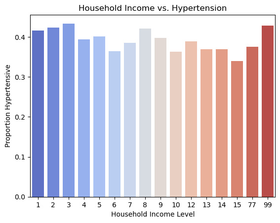

```python
sns.barplot(x="INDHHIN2", y="Hypertension", data=merged_df, ci=None, palette="coolwarm")
plt.xlabel("Household Income Level")
plt.ylabel("Proportion Hypertensive")
plt.title("Household Income vs. Hypertension")
plt.show()
```

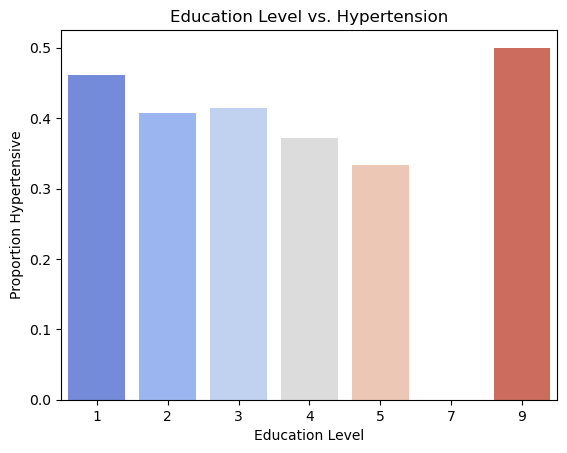

```python
sns.barplot(x="DMDEDUC2", y="Hypertension", data=merged_df, ci=None, palette="coolwarm")
plt.xlabel("Education Level")
plt.ylabel("Proportion Hypertensive")
plt.title("Education Level vs. Hypertension")
plt.show()
```

```python
from scipy.stats import chi2_contingency

# Chi-Square Test for Income vs Hypertension
income_contingency = pd.crosstab(merged_df["INDHHIN2"], merged_df["Hypertension"])
chi2_income, p_income, _, _ = chi2_contingency(income_contingency)
print(f"Chi-Square Test (Income): p-value = {p_income}")

# Chi-Square Test for Education vs Hypertension
edu_contingency = pd.crosstab(merged_df["DMDEDUC2"], merged_df["Hypertension"])
chi2_edu, p_edu, _, _ = chi2_contingency(edu_contingency)
print(f"Chi-Square Test (Education): p-value = {p_edu}")
```

```
Chi-Square Test (Income): p-value = 0.3375088692728001
Chi-Square Test (Education): p-value = 6.805239975752151e-05
```

```python
import numpy as np
from scipy.stats import chi2_contingency

# Compute Cramér's V
def cramers_v(chi2, n, k1, k2):
    return np.sqrt(chi2 / (n * min(k1 - 1, k2 - 1)))

n = len(merged_df)
k1 = len(merged_df["DMDEDUC2"].unique())
k2 = len(merged_df["Hypertension"].unique())

cramers_v_value = cramers_v(chi2_edu, n, k1, k2)
print(f"Cramér's V (Effect Size for Education & Hypertension) = {cramers_v_value}")
```

```
Cramér's V (Effect Size for Education & Hypertension) = 0.0787817931327048
```

```python
# Load the examination dataset and check column names
exam_df = pd.read_csv("examination.csv", encoding="latin1")

# Print all column names
print(exam_df.columns)
```

```
Index(['SEQN', 'PEASCST1', 'PEASCTM1', 'PEASCCT1', 'BPXCHR', 'BPAARM',
       'BPACSZ', 'BPXPLS', 'BPXPULS', 'BPXPTY',
       ...
       'CSXLEAOD', 'CSXSOAOD', 'CSXGRAOD', 'CSXONOD', 'CSXNGSOD', 'CSXSLTRT',
       'CSXSLTRG', 'CSXNART', 'CSXNARG', 'CSAEFFRT'],
      dtype='object', length=224)
```

```python
# Keep only relevant columns (Participant ID + BMI)
exam_df = exam_df[["SEQN", "BMXBMI"]]

# Merge with the main dataset on SEQN (participant ID)
merged_df = merged_df.merge(exam_df, on="SEQN", how="inner")

# Verify merge success
print(merged_df[["SEQN", "BMXBMI", "Hypertension"]].head())
```

```
    SEQN  BMXBMI  Hypertension
0  73557    26.7             0
1  73558    28.6             1
2  73559    28.9             1
3  73561    19.7             1
4  73562    41.7             1
```

```python
# Count missing values
print("Missing BMI values:", merged_df["BMXBMI"].isna().sum())

# Drop missing values
merged_df = merged_df.dropna(subset=["BMXBMI"])

# Ensure BMI is in correct format
merged_df["BMXBMI"] = merged_df["BMXBMI"].astype(float)
```

```
Missing BMI values: 32
```

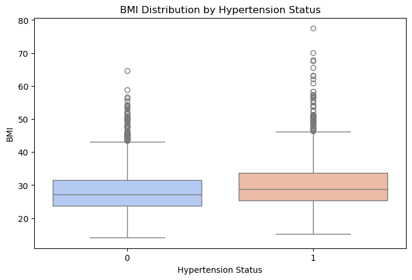

```python
import seaborn as sns
import matplotlib.pyplot as plt

plt.figure(figsize=(8, 5))
sns.boxplot(x=merged_df["Hypertension"], y=merged_df["BMXBMI"], palette="coolwarm")
plt.xlabel("Hypertension Status")
plt.ylabel("BMI")
plt.title("BMI Distribution by Hypertension Status")
plt.show()
```

```python
from scipy.stats import ttest_ind

# Separate groups
bmi_hyp = merged_df[merged_df["Hypertension"] == 1]["BMXBMI"]
bmi_nonhyp = merged_df[merged_df["Hypertension"] == 0]["BMXBMI"]

# Perform t-test
t_test_bmi = ttest_ind(bmi_hyp, bmi_nonhyp, equal_var=False, nan_policy="omit")

print(f"T-test (BMI & Hypertension) - p-value: {t_test_bmi.pvalue}")
```

```
T-test (BMI & Hypertension) - p-value: 8.210561052181232e-20
```

```python
from numpy import mean, std
from math import sqrt

# Function to compute Cohen's d
def cohen_d(group1, group2):
    return (mean(group1) - mean(group2)) / sqrt((std(group1, ddof=1) ** 2 + std(group2, ddof=1) ** 2) / 2)

# Compute effect size
effect_size_bmi = cohen_d(bmi_hyp.dropna(), bmi_nonhyp.dropna())

print(f"Effect Size (Cohen's d) for BMI & Hypertension: {effect_size_bmi}")
```

```
Effect Size (Cohen's d) for BMI & Hypertension: 0.2827242367017534
```

```python
# Select relevant columns for modeling
features = ["DMDEDUC2", "INDHHIN2", "BMXBMI", "DR1TSODI",
            "PAQ605", "PAQ620", "HIQ011", "HUQ030"]
target = "Hypertension"

# Drop rows with missing values in selected features
merged_df = merged_df.dropna(subset=features + [target])

# Display the updated dataset shape
print("Dataset shape after handling missing values:", merged_df.shape)

# Display the first few rows to verify
print(merged_df[features + [target]].head())
```

```
Dataset shape after handling missing values: (4599, 400)
   DMDEDUC2  INDHHIN2  BMXBMI  DR1TSODI PAQ605  PAQ620  HIQ011  HUQ030  \
0         3         4    26.7    1323.0      2       2       1       1
1         3         7    28.6    9726.0      2       1       0       1
2         4        10    28.9    2943.0      2       1       1       1
3         5        15    19.7     797.0      2       1       1       1
4         4         9    41.7    2651.0      1       2       1       1

   Hypertension
0             0
1             1
2             1
3             1
4             1
```

```python
# Convert categorical variables to appropriate data types
merged_df["DMDEDUC2"] = merged_df["DMDEDUC2"].astype(int)  # Education Level
merged_df["HUQ030"] = merged_df["HUQ030"].astype(int)  # General Health (1 = Excellent, 5 = Poor)

# Verify the data types after conversion
print(merged_df[features].dtypes)

# Display first few rows to confirm
print(merged_df.head())
```

```
DMDEDUC2       int64
INDHHIN2       int64
BMXBMI       float64
DR1TSODI     float64
PAQ605      category
PAQ620         int64
HIQ011         int64
HUQ030         int64
dtype: object
    SEQN        WTDRD1        WTDR2D  DR1DRSTZ  DR1EXMER  DRABF  DRDINT  \
0  73557  16888.327864  12930.890649         1      49.0    2.0     2.0
1  73558  17932.143865  12684.148869         1      59.0    2.0     2.0
2  73559  59641.812930  39394.236709         1      49.0    2.0     2.0
3  73561  59052.357033  39004.892993         1      63.0    2.0     2.0
4  73562  49890.828664      0.000000         1      49.0    2.0     1.0

   DR1DBIH  DR1DAY  DR1LANG  ...  CSAEFFRT  Hypertension  PAQ605  PAQ620  \
0      6.0     2.0      1.0  ...       1.0             0       2       2
1      4.0     1.0      1.0  ...       1.0             1       2       1
2     18.0     6.0      1.0  ...       3.0             1       2       1
3     18.0     1.0      1.0  ...       1.0             1       2       1
4     11.0     3.0      1.0  ...       1.0             1       1       2

   HIQ011  HUQ030  INDHHIN2  DMDEDUC2  BMXBMI_y  BMXBMI
0       1       1         4         3      26.7    26.7
1       0       1         7         3      28.6    28.6
2       1       1        10         4      28.9    28.9
3       1       1        15         5      19.7    19.7
4       1       1         9         4      41.7    41.7

[5 rows x 400 columns]
```

```python
 from sklearn.model_selection import train_test_split

# Define X (features) and y (target)
X = merged_df[features]
y = merged_df[target]

# Split data into 80% training, 20% testing
X_train, X_test, y_train, y_test = train_test_split(X, y, test_size=0.2, random_state=42)

# Display the shape of the splits
print("Training Data Shape:", X_train.shape)
print("Testing Data Shape:", X_test.shape)
```

```
Training Data Shape: (3679, 8)
Testing Data Shape: (920, 8)
```

```python
from sklearn.linear_model import LogisticRegression
from sklearn.preprocessing import StandardScaler

# Standardize the features (important for logistic regression)
scaler = StandardScaler()
X_train_scaled = scaler.fit_transform(X_train)
X_test_scaled = scaler.transform(X_test)

# Initialize and train the Logistic Regression model
log_reg = LogisticRegression()
log_reg.fit(X_train_scaled, y_train)

# Print training
print("Logistic Regression model trained successfully!")
```

```
Logistic Regression model trained successfully!
```

```python
from sklearn.metrics import accuracy_score, precision_score, recall_score, f1_score, confusion_matrix, classification_report

# Make predictions on the test set
y_pred = log_reg.predict(X_test_scaled)

# Compute performance metrics
accuracy = accuracy_score(y_test, y_pred)
precision = precision_score(y_test, y_pred)
recall = recall_score(y_test, y_pred)
f1 = f1_score(y_test, y_pred)

# Display results
print(f"Accuracy: {accuracy:.4f}")
print(f"Precision: {precision:.4f}")
print(f"Recall: {recall:.4f}")
print(f"F1 Score: {f1:.4f}")

# Display confusion matrix
print("\nConfusion Matrix:")
print(confusion_matrix(y_test, y_pred))

# Display classification report
print("\nClassification Report:")
print(classification_report(y_test, y_pred))
```

```
Accuracy: 0.6098
Precision: 0.5122
Recall: 0.1163
F1 Score: 0.1896

Confusion Matrix:
[[519  40]
 [319  42]]

Classification Report:
              precision    recall  f1-score   support

           0       0.62      0.93      0.74       559
           1       0.51      0.12      0.19       361

    accuracy                           0.61       920
   macro avg       0.57      0.52      0.47       920
weighted avg       0.58      0.61      0.53       920
```

## Reflections and Future Improvements

### Model Performance and Areas for Improvement

The final logistic regression model performed with an accuracy of approximately **61%**, with a recall score on hypertensive cases that remained quite low. This suggests that while the model is decent at identifying non-hypertensive individuals, it struggles with correctly classifying those with hypertension. The relatively low **precision and recall** for the hypertensive class further indicate that the model is not capturing the most important risk factors effectively.

To improve the model in the future, I plan to:

- **Explore additional feature engineering techniques**: Combining existing features or transforming variables (e.g., binning continuous variables into categories) might improve the model’s ability to differentiate between classes.
- **Incorporate external data sources**: Bringing in more granular data on lifestyle factors, genetics, or environmental conditions could improve prediction accuracy.
- **Try different machine learning models**: A decision tree-based approach, such as **Random Forest** or **XGBoost**, might capture non-linear relationships better than logistic regression.
- **Balance the dataset**: Given the imbalance in hypertensive vs. non-hypertensive cases, applying oversampling (SMOTE) or cost-sensitive learning techniques could enhance model performance.

### Key Takeaways

This project was an insightful exercise in **feature selection, statistical analysis, and model evaluation**. While finding meaningful predictors was more challenging than anticipated, the process reinforced the importance of rigorous testing and domain knowledge in data science. Moving forward, I will refine the model by integrating new approaches and further optimizing feature selection to improve classification accuracy.